# STATS506_hw4

Author

Xingjian Liu

```r
knitr::opts_chunk$set(error=TRUE)
```

GitHub: https://github.com/CherryLIUxj/STATS506_proj/tree/master

# Problem 1 - TidyVerse

Use the **tidyverse** for this problem. In particular, use piping and **dplyr** as much as you are able. **Note**: Use of any deprecated functions will result in a point loss.

Install and load the package [**nycflights13**](https://cran.r-project.org/package=nycflights13).

## a.

Generate a table (which can just be a nicely printed tibble) reporting the mean and median departure delay per airport. Generate a second table (which again can be a nicely printed tibble) reporting the mean and median arrival delay per airport. *Exclude any destination with under 10 flights*. Do this exclusion through code, not manually.

Additionally,

- Order both tables in descending mean delay.
- Both tables should use the airport *names* not the airport *codes*.
- Both tables should print all rows.

```r
install.packages("nycflights13")
```

[output not shown]

```r
library(nycflights13)
```

```r
library(tidyverse)
```

```r
data(flights)
data(airports)
```

```r
names(flights)
```

```
 [1] "year"           "month"          "day"            "dep_time"
 [5] "sched_dep_time" "dep_delay"      "arr_time"       "sched_arr_time"
 [9] "arr_delay"      "carrier"        "flight"         "tailnum"
[13] "origin"         "dest"           "air_time"       "distance"
[17] "hour"           "minute"         "time_hour"
```

```r
# origin: departure airport code; dest: arrival airport code
```

```r
names(airports)
```

```
[1] "faa"   "name"  "lat"   "lon"   "alt"   "tz"    "dst"   "tzone"
```

```r
# faa: airport code; name: airport name
```

```r
# calculate mean and median depature delay
dep_delay_stat <- flights %>%
  group_by(origin) %>%
  summarize(mean_dep_delay=mean(dep_delay,na.rm=TRUE),median_dep_delay=median(dep_delay,na.rm=TRUE)) %>%
  arrange(desc(mean_dep_delay)) %>%
  inner_join(airports, by=c('origin'='faa')) %>%
  select(name,mean_dep_delay,median_dep_delay)
print(dep_delay_stat,n=Inf)
```

```
# A tibble: 3 × 3
  name                mean_dep_delay median_dep_delay
  <chr>                        <dbl>            <dbl>
1 Newark Liberty Intl           15.1               -1
2 John F Kennedy Intl           12.1               -1
3 La Guardia                    10.3               -3
```

```r
arr_delay_stat <- flights %>%
  group_by(dest) %>%
  summarize(mean_arr_delay=mean(arr_delay,na.rm=TRUE),median_arr_delay=median(arr_delay,na.rm=TRUE), total_flights=n()) %>%
  filter(total_flights>=10) %>%
  select(dest,mean_arr_delay,median_arr_delay) %>%
  arrange(desc(mean_arr_delay)) %>%
  inner_join(airports, by=c('dest'='faa')) %>%
  select(name,mean_arr_delay,median_arr_delay)
print(arr_delay_stat,n=Inf)
```

```
# A tibble: 98 × 3
   name                                   mean_arr_delay median_arr_delay
   <chr>                                           <dbl>            <dbl>
 1 "Columbia Metropolitan"                       41.8                28
 2 "Tulsa Intl"                                  33.7                14
 3 "Will Rogers World"                           30.6                16
 4 "Jackson Hole Airport"                        28.1                15
 5 "Mc Ghee Tyson"                               24.1                 2
 6 "Dane Co Rgnl Truax Fld"                      20.2                 1
 7 "Richmond Intl"                               20.1                 1
 8 "Akron Canton Regional Airport"               19.7                 3
 9 "Des Moines Intl"                             19.0                 0
10 "Gerald R Ford Intl"                          18.2                 1
11 "Birmingham Intl"                             16.9                -2
12 "Theodore Francis Green State"                16.2                 1
```

[output cut: 86 more lines]

## b.

How many flights did the aircraft model with the fastest average speed take? Produce a tibble with 1 row, and entires for the model, average speed (in MPH) and number of flights.

```r
data(planes)
```

```r
names(planes)
```

```
[1] "tailnum"      "year"         "type"         "manufacturer" "model"
[6] "engines"      "seats"        "speed"        "engine"
```

```r
# average speed = distance / time
# time = air_time (minute to hour)

flights_model <- flights %>%
  inner_join(planes, by='tailnum') %>%
  filter(!is.na(air_time)) %>%
  mutate(speed=distance/(air_time/60)) %>%
  group_by(model) %>%
  summarize(avg_speed=mean(speed),total_flights=n()) %>%
  arrange(desc(avg_speed)) %>%
  select(model,avg_speed,total_flights) %>%
  filter(avg_speed==max(avg_speed))

flights_model
```

```
# A tibble: 1 × 3
  model   avg_speed total_flights
  <chr>       <dbl>         <int>
1 777-222      483.             4
```

# Problem 2 - **`get_temp()`**

Use the **tidyverse** for this problem. In particular, use piping and **dplyr** as much as you are able. **Note**: Use of any deprecated functions will result in a point loss.

Load the Chicago NNMAPS data we used in the visualization lectures. Write a function `get_temp()` that allows a user to request the average temperature for a given month. The arguments should be:

- `month`: Month, either a numeric 1-12 or a string.
- `year`: A numeric year.
- `data`: The data set to obtain data from.
- `celsius`: Logically indicating whther the results should be in celsius. Default `FALSE`.
- `average_fn`: A function with which to compute the mean. Default is `mean`.

The output should be a numeric vector of length 1. The code inside the function should, as with the rest of this problem, use the **tidyverse**. Be sure to sanitize the input.

Prove your code works by evaluating the following. Your code should produce the result, or a reasonable error message.

```r
nnmaps <- readr::read_delim('chicago-nmmaps.csv')
```

```r
table(nnmaps$year)
```

```
1997 1998 1999 2000
 365  365  365  366
```

```r
get_temp <- function(month,year,data,celsius=FALSE,average_fn=mean){if (is.double(month)){
  data %>%
    mutate(year_numeric=as.integer(year)) %>%
    group_by(year_numeric,month_numeric) %>%
    summarize(average_temp=average_fn(temp), .groups = "drop") %>%
    mutate(celsius_=celsius) %>%
    mutate(average_temp=if_else(celsius_==1,(average_temp-30)*5/9,average_temp)) %>%
    filter(month_numeric==month,year_numeric==year) %>%
    pull(average_temp)
}
  else{
  data %>%
    rename(month_name=month) %>%
    mutate(year_numeric=as.integer(year)) %>%
    group_by(year_numeric,month_name) %>%
    summarize(average_temp=average_fn(temp),.groups = "drop") %>%
    mutate(celsius_=celsius) %>%
    mutate(average_temp=if_else(celsius_==1,(average_temp-30)*5/9,average_temp)) %>%
    filter(month_name==substr(month,start=1,stop=3),year_numeric==year) %>%
    pull(average_temp)
}

}
```

```r
get_temp("Apr", 1999, data = nnmaps)
```

```
[1] 49.8
```

```r
get_temp("Apr", 1999, data = nnmaps, celsius = TRUE)
```

```
[1] 11
```

```r
get_temp(10, 1998, data = nnmaps, average_fn = median)
```

```
[1] 55
```

```r
get_temp(13, 1998, data = nnmaps)
```

```
numeric(0)
```

```r
get_temp(2, 2005, data = nnmaps)
```

```
numeric(0)
```

```r
get_temp("November", 1999, data =nnmaps, celsius = TRUE,
         average_fn = function(x) {
           x %>% sort -> x
           x[2:(length(x) - 1)] %>% mean %>% return
         })
```

```
[1] 8.412698
```

# Problem 3 - SAS

This problem should be done entirely within SAS.

Access the [RECS 2020 data](https://www.eia.gov/consumption/residential/data/2020/index.php?view=microdata) and download a copy of the data. You may import the CSV or load in the sas7bdat file directly. (This is **not** the 2009 version we used in lecture.) You'll probably also need the "Variable and response cookbook" to identify the proper variables. Load or import the data into SAS.

```r
%let in_path = ~/stats506/HW4/;
%let out_path = ~/stats506/HW4/output/;

libname in_lib "&in_path.";
libname out_lib "&out_path.";
```

## a.

What state has the highest percentage of records? What percentage of all records correspond to Michigan? (Don't forget to account for the sampling weights!)

```r
proc sql;
    select sum(nweight) into :total
    from in_lib.recs2020_public_v5;
quit;


proc summary data=in_lib.recs2020_public_v5;
    class state_name;
    output out=state_records
        sum(nweight) = num;
run;

data state_freq;
    set state_records;
    freq = num/&total;
run;

proc sort
    data=state_freq
    out=out_lib.state_freq;
    by descending freq;
run;

proc print data=out_lib.state_freq(FIRSTOBS=2 OBS=2); /* obs=1 is the sum */
run;

proc print data=state_freq;
    where state_name='Michigan';
run;
```

## b. Generate a histogram of the total electricity cost in dollars, amongst those with a strictly positive cost.

```r
data elcost;
    set in_lib.recs2020_public_v5;
    where dollarel > 0;
run;

proc univariate data=elcost;
    var dollarel;
    histogram;
run;
```

## c. Generate a histogram of the log of the total electricity cost.

```r
data elcost_log;
    set elcost;
    log_dollarel = log(dollarel);
run;

proc univariate data=elcost_log;
    var log_dollarel;
    histogram;
run;
```

## d. Fit a linear regression model predicting the log of the total electricity cost based upon the number of rooms in the house and whether or not the house has a garage. (Don't forget weights.)

```r
proc reg data=elcost_log;
    weight nweight;
    model log_dollarel = totrooms PRKGPLC1;
run;
quit;
```

## e. Use that model to generate predicted values and create a scatterplot of predicted total electricity cost vs actual total electricity cost (**not** on the log scale).

```r
data pred_elcost;
    set elcost_log;
    pred_dollarel = exp(6.51523 + 0.08780*totrooms + 0.06878*PRKGPLC1);
run;

proc sgplot data=pred_elcost;
    scatter X=dollarel Y=pred_dollarel;
    reg X=dollarel Y=pred_dollarel / degree=1;
    title "Scatter Plot of fitted values vs actual values with Regression Line";
run;
```

# Problem 4 - Multiple Tools

It is not uncommon during an analysis to use multiple statistical tools as each has their own pros and cons. The problem is based on an actual analysis I've done, with a different data set. The data was originally stored in a large SAS database, but the researcher was most familiar with Stata so I carried out the analysis there. During the course of the project, there was a particular analysis that Stata could not do, so I switched over to R. We're going to mimic this workflow here.

We'll use the Survey of Household Economics and Decisionmaking from the Federal Resereve. The data and Codebook documentation can be found at https://www.federalreserve.gov/consumerscommunities/shed_data.htm. Use the 2022 version.

The researcher's interest is in whether long-term concerns about climate change impact current day concerns about financial stability. To address this, the particular research question of interest is whether **the respondent's family is better off, the same, or worse off finanicially compared to 12 month's ago** can be predicted by **thinking that the chance of experiencing a natural disaster or severe weather event will be higher, lower or about the same in 5 years**. We also want to control for

- How they rate the economic conditions today in the country.
- Whether they own (with or without a mortgage) or rent or neither their home.
- Education (use the 4-category version)
- Race (use the 5-category version)

We're going to pretend the raw data is extremely large and that we need to extract the subset of the data we're going to use before we can open it in Stata or R.

Additionally, the data comes from a complex survey design, so we need to account for that in the analysis.

## a.

Take a look at the Codebook. For very minor extra credit, how was the Codebook generated? (No loss of points if you skip this.)

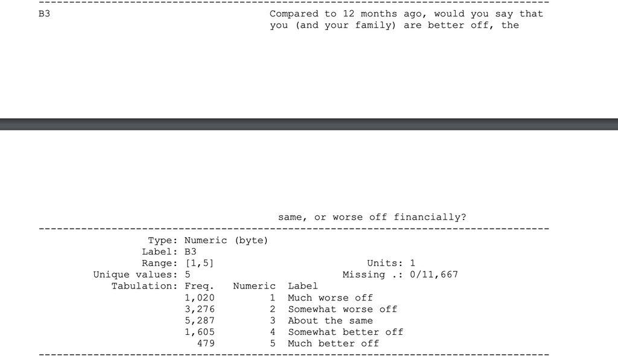

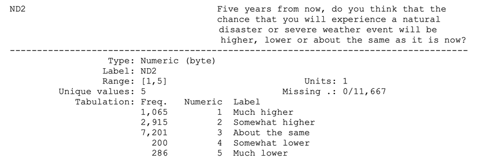

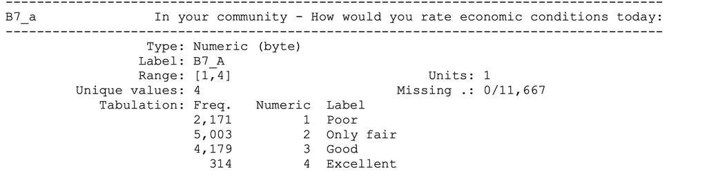

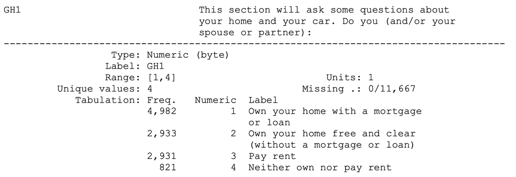

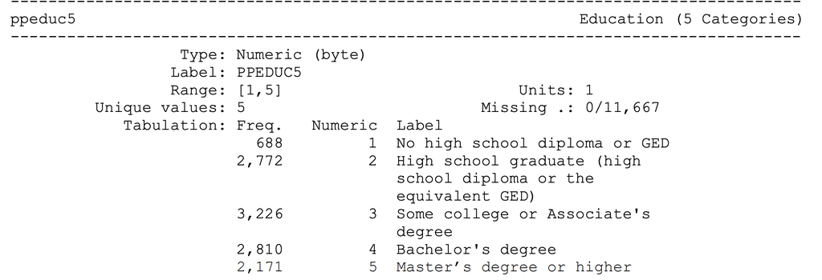

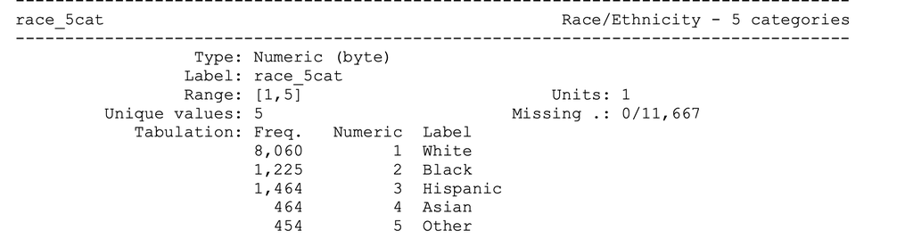

**Response**: B3 (Compared to 12 months ago, would you say that you (and your family) are better off, the same, or worse off financially?)

**Predictors**:

ND2 (Five years from now, do you think that the chance that you will experience a natural disaster or severe weather event will be higher, lower or about the same as it is now?)

B7_a (In your community - How would you rate economic conditions today)

GH1 (Whether they own (with or without a mortgage) or rent or neither their home.)

ppeducat (Education (4-category))

race_5cat (Race / Ethnicity (5-category))